None

```python
import pandas as pd
import geopandas as gpd
pd.set_option("max_colwidth", 200)

import json
import requests

import psycopg2
import keyring

from shapely.geometry import LineString
from shapely import wkt

import plotly.graph_objects as go
import matplotlib.pyplot as plt
import matplotlib.patches as mpatches
plt.rcParams["figure.figsize"] = (20, 20)
plt.rcParams["font.size"] = 15

def minmax(vals, min_a = 0, max_a = 1):
    Z = max(vals) - min(vals)
    out_vals = (vals - min(vals))/Z*(max_a - min_a) + min_a
    return out_vals

colors = [
    [255,0,0],
    [255,255,0],
    [0,234,255],
    [170,0,255],
    [255,127,0],
    [191,255,0],
    [0,149,255],
    [255,0,170],
    [255,212,0],
    [106,255,0],
    [0,64,255],
    [237,185,185],
    [185,215,237],
    [231,233,185],
    [220,185,237],
    [185,237,224],
    [143,35,35],
    [35,98,143],
    [143,106,35],
    [107,35,143],
    [79,143,35],
    [0,0,0],
    [115,115,115],
    [204,204,204]
]

for ii, color in enumerate(colors):
    for jj, entry in enumerate(color):
        colors[ii][jj] = entry/255
```

# Introduction

I use the SCB API to get data over migration patterns between Swedish counties.  
The data contains "OD-pairs" for migrationns aggregated by years.

# Get county map

Since we want to show the spatial migration pattern between Swedish counties we need to create a map with each county.  
The data for each county will be mapped to the centroid.

To create a map of the migration patterns we load the county data from a postgis database.  
In this step we also extract the centroids of all the county polygons

The map is loaded from a PostGIS database with official Swedish county geometries.  
Although we could get the centroids from PostGIS with the function `ST_centroid()`.  
Geopandas also supports returning centroid of the dataframe geometry.

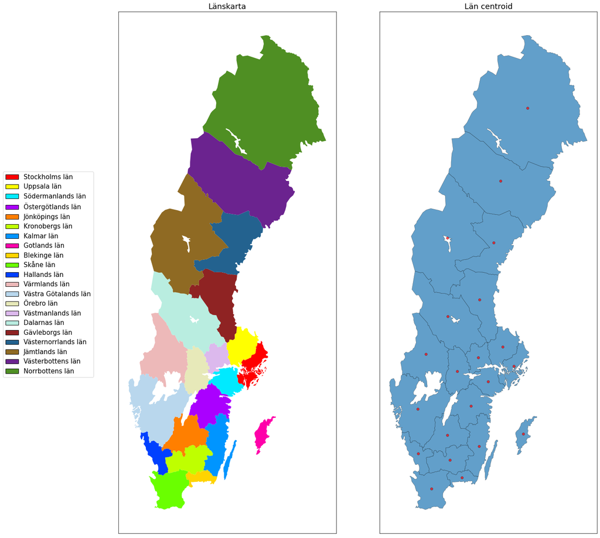

```python
conn = psycopg2.connect(host="localhost", database="sverige", user="michael", password = keyring.get_password("pgsql", "michael"))
q = "SELECT * FROM lan_sweref99TM_region"
gdf = gpd.GeoDataFrame.from_postgis(q, conn, geom_col="geom")
gdf["lnnamn"]  += " län"  # To conform to SCB naming
gdf["centroid"] = gdf.centroid

fig,ax = plt.subplots(1, 2, figsize=(20, 30))

colormap = {ln: colors[ii] for ii, ln in enumerate(gdf.lnnamn.values)}

kwargs = {
    'edgecolor': 'black',
    'alpha': 0.7,
    'linewidth': 0.4
}


gdf.plot(
    ax = ax[0],
    color = gdf["lnnamn"].map(colormap)
)

pmark = []
handles = []
for name in gdf.lnnamn.values:
    pmark.append(
        mpatches.Patch(
            facecolor=colormap[name],
            label=name,
            edgecolor="black"
        )
    )

    handles.append(name)

leg = ax[0].legend(handles=pmark, labels=handles, bbox_to_anchor=(-.1,.7))

ax[0].set(xticks = [], yticks = [], title="Länskarta")

gdf.plot(ax = ax[1], **kwargs)

ax[1].set(xticks = [], yticks = [], title="Län centroid")
gdf.centroid.plot(ax = ax[1], facecolor="red", **kwargs)

plt.show()
```

# Get SCB migration data

We use the post method where the query parameters are in a separate body than the query string. According to the documentation, an API URL should have the format:

```
API-NAME/API-VERSION/LANGUAGE/DATABASEID/<LEVELS>/TABLE-ID
```

where,

- API-NAME: Defines the root name of the API.
- API-VERSION: Self explanatory. It's the API version.
- LANGUAGE: Defines the langage of the data collection. Commonly "doris"
- DATABASE-ID: Specifies the ID of the database containing the statistical tables.
- LEVELS: defines zero or more levels in the database.
- TABLE-ID: Defines the ID of a statistics table.

For example:

```
url = "http://api.scb.se/OV0104/v1/doris/sv/ssd/START/BE/BE0101/BE0101J/InOmflytt"
```

Would mean that:

- API-Name = "OV0104"
- API-VERSION = "v1"
- LANGAUGE = "doris

Below the migration data for 2020 is collected.

```python
url = "http://api.scb.se/OV0104/v1/doris/sv/ssd/START/BE/BE0101/BE0101J/InOmflytt"

values = {
  "query": [
    {
      "code": "InflyttningsL",
      "selection": {
        "filter": "all",
        "values": ["*"]
      }
    },
    {
      "code": "UtflyttningsL",
      "selection": {
        "filter": "item",
        "values": [
          '01',
         '03',
         '04',
         '05',
         '06',
         '07',
         '08',
         '09',
         '10',
         '12',
         '13',
         '14',
         '17',
         '18',
         '19',
         '20',
         '21',
         '22',
         '23',
         '24',
         '25'
        ]
      }
    },
    {
      "code": "Tid",
      "selection": {
        "filter": "item",
        "values": [
         "2020"
        ]
      }
    }
  ],
    "response": {
        "format": "json-stat"
    }
}
```

```python
dataset = requests.post(url, json=values).json()["dataset"]
ind_in = dataset["dimension"]["InflyttningsL"]["category"]["index"]
ind_ut = dataset["dimension"]["UtflyttningsL"]["category"]["index"]

df_2020 = pd.DataFrame(np.array(dataset["value"]).reshape((len(ind_in), len(ind_ut))))

df_2020.columns = ["In_" + "_".join(x.split()[:-1]) for x in list(dataset["dimension"]["InflyttningsL"]["category"]["label"].values())]
df_2020.index = ["Ut_" + "_".join(x.split()[:-1]) for x in list(dataset["dimension"]["UtflyttningsL"]["category"]["label"].values())]

df_2020
```

|  | In_Stockholms_län | In_Uppsala_län | In_Södermanlands_län | In_Östergötlands_län | In_Jönköpings_län | In_Kronobergs_län | In_Kalmar_län | In_Gotlands_län | In_Blekinge_län | In_Skåne_län | ... | In_Västra_Götalands_län | In_Värmlands_län | In_Örebro_län | In_Västmanlands_län | In_Dalarnas_län | In_Gävleborgs_län | In_Västernorrlands_län | In_Jämtlands_län | In_Västerbottens_län | In_Norrbottens_län |
| --- | --- | --- | --- | --- | --- | --- | --- | --- | --- | --- | --- | --- | --- | --- | --- | --- | --- | --- | --- | --- | --- |
| Ut_Stockholms_län | 0 | 6706 | 3750 | 3222 | 1224 | 792 | 1045 | 749 | 524 | 4867 | ... | 5648 | 1159 | 1935 | 1991 | 1688 | 1824 | 1263 | 783 | 1499 | 1267 |
| Ut_Uppsala_län | 7945 | 0 | 544 | 498 | 240 | 116 | 176 | 179 | 100 | 779 | ... | 1024 | 287 | 439 | 1065 | 867 | 1411 | 519 | 295 | 382 | 395 |
| Ut_Södermanlands_län | 5581 | 476 | 0 | 933 | 153 | 127 | 164 | 74 | 68 | 424 | ... | 604 | 146 | 471 | 769 | 232 | 193 | 178 | 84 | 168 | 154 |
| Ut_Östergötlands_län | 3358 | 466 | 961 | 0 | 1170 | 282 | 822 | 93 | 129 | 974 | ... | 1349 | 270 | 628 | 416 | 270 | 235 | 192 | 134 | 190 | 243 |
| Ut_Jönköpings_län | 1254 | 226 | 193 | 1066 | 0 | 673 | 583 | 32 | 178 | 1025 | ... | 2342 | 150 | 270 | 139 | 134 | 131 | 124 | 105 | 146 | 115 |
| Ut_Kronobergs_län | 675 | 89 | 91 | 302 | 767 | 0 | 702 | 51 | 528 | 1733 | ... | 750 | 91 | 127 | 56 | 120 | 59 | 46 | 56 | 73 | 62 |
| Ut_Kalmar_län | 1388 | 194 | 152 | 788 | 443 | 639 | 0 | 117 | 525 | 943 | ... | 769 | 82 | 135 | 97 | 121 | 80 | 82 | 54 | 134 | 113 |
| Ut_Gotlands_län | 1219 | 216 | 90 | 66 | 42 | 35 | 115 | 0 | 19 | 135 | ... | 210 | 24 | 40 | 57 | 53 | 36 | 42 | 40 | 50 | 30 |
| Ut_Blekinge_län | 489 | 88 | 69 | 101 | 148 | 443 | 438 | 25 | 0 | 1718 | ... | 418 | 51 | 65 | 61 | 49 | 34 | 45 | 33 | 58 | 41 |
| Ut_Skåne_län | 5788 | 831 | 478 | 988 | 1300 | 1979 | 1210 | 154 | 1871 | 0 | ... | 4450 | 447 | 529 | 415 | 442 | 294 | 322 | 237 | 482 | 393 |
| Ut_Hallands_län | 883 | 140 | 111 | 245 | 635 | 443 | 174 | 31 | 186 | 1840 | ... | 5446 | 138 | 157 | 95 | 135 | 67 | 72 | 69 | 97 | 105 |
| Ut_Västra_Götalands_län | 4926 | 924 | 659 | 1460 | 2409 | 920 | 788 | 203 | 523 | 3862 | ... | 0 | 1692 | 1316 | 530 | 692 | 462 | 483 | 405 | 754 | 539 |
| Ut_Värmlands_län | 1252 | 240 | 169 | 256 | 167 | 72 | 85 | 36 | 51 | 357 | ... | 1796 | 0 | 874 | 192 | 305 | 102 | 85 | 83 | 85 | 103 |
| Ut_Örebro_län | 1864 | 373 | 516 | 599 | 246 | 78 | 135 | 52 | 60 | 405 | ... | 1132 | 916 | 0 | 735 | 511 | 189 | 149 | 119 | 165 | 132 |
| Ut_Västmanlands_län | 2234 | 1072 | 1026 | 321 | 135 | 101 | 115 | 42 | 41 | 327 | ... | 548 | 220 | 679 | 0 | 780 | 287 | 152 | 127 | 197 | 138 |
| Ut_Dalarnas_län | 2033 | 631 | 205 | 258 | 113 | 58 | 99 | 42 | 40 | 315 | ... | 633 | 274 | 370 | 741 | 0 | 522 | 127 | 170 | 164 | 144 |
| Ut_Gävleborgs_län | 2168 | 1198 | 171 | 202 | 93 | 60 | 61 | 50 | 67 | 228 | ... | 473 | 130 | 172 | 225 | 648 | 0 | 486 | 258 | 295 | 168 |
| Ut_Västernorrlands_län | 1394 | 368 | 119 | 160 | 75 | 55 | 57 | 53 | 19 | 266 | ... | 397 | 60 | 84 | 133 | 158 | 538 | 0 | 463 | 776 | 286 |
| Ut_Jämtlands_län | 1128 | 250 | 122 | 144 | 76 | 33 | 47 | 43 | 23 | 227 | ... | 458 | 91 | 83 | 102 | 178 | 218 | 487 | 0 | 315 | 110 |
| Ut_Västerbottens_län | 1584 | 329 | 155 | 164 | 98 | 74 | 82 | 62 | 37 | 428 | ... | 675 | 88 | 128 | 129 | 177 | 274 | 953 | 302 | 0 | 1356 |
| Ut_Norrbottens_län | 1227 | 298 | 117 | 190 | 98 | 54 | 53 | 47 | 67 | 320 | ... | 602 | 111 | 114 | 127 | 141 | 175 | 235 | 129 | 1006 | 0 |

21 rows × 21 columns

# Migration size from Stockholm.

With this data, we can create a map showing the size of the migration from Stockholm to each respective county.  
The size of the circle marker, as well as the opacity, show the size of the flow.

Getting the geometry correct took a bit of work to figure out.  
The main difficulty was in getting the linestring between each county to clip at the circle boundary.  
Without this, the line went to the center of the circle polygon and was visible.

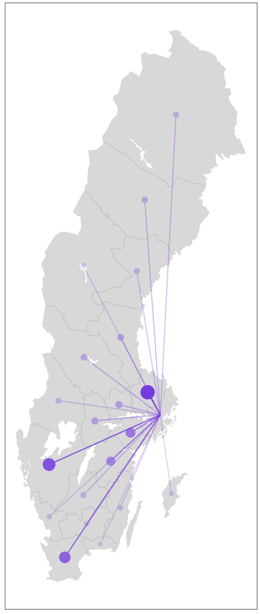

```python
df = df_2020.unstack().reset_index()

df.columns = ["In", "Ut", "N"]

df["In"] = df["In"].apply(lambda x: x[3:].replace("_", " "))
df["Ut"] = df["Ut"].apply(lambda x: x[3:].replace("_", " "))
df.In.unique()

mov = df.merge(gdf[["lnnamn", "centroid"]], left_on="In", right_on="lnnamn")
mov = mov.merge(gdf[["lnnamn", "centroid"]], left_on="Ut", right_on="lnnamn")
mov = mov[mov["N"] != 0 ]
mov = gpd.GeoDataFrame(mov)

mov["geometry"] = mov.apply(lambda row: LineString((row.centroid_x, row.centroid_y)), axis=1)

mov = mov.set_crs("epsg:3006")

bkr_kwargs = dict(
    facecolor = "grey",
    alpha = 0.3,
    edgecolor = "black",
    linewidth = 0.3
)

lan = "Stockholms"

df_plot = mov[(mov["Ut"].str.contains(lan)) & (~mov["In"].str.contains(lan))].copy()

rgba_colors = np.zeros((len(df_plot.index), 4))
rgba_colors[:, 3] = minmax(df_plot["N"], min_a = 0.2, max_a = 1)
for ii, col in enumerate((119, 58, 223)):
    rgba_colors[:, ii] = col/255

df_plot["size"] = minmax(df_plot["N"].values, 7000, 20000)
df_plot["centroid_buffer"] = df_plot.apply(lambda x: x["centroid_x"].buffer(x["size"]), axis=1)
df_plot["clipped_lines"] = df_plot.apply(lambda x: x["geometry"].difference(x["centroid_buffer"]), axis=1)


fig, ax = plt.subplots(figsize = (25, 25))
ax.set(xticks = [], yticks = [])

gdf.plot(ax = ax, **bkr_kwargs)

df_plot.set_geometry("clipped_lines").plot(
    ax = ax,
    color = rgba_colors,
    linewidth = 2.5,
    zorder = 3,
)

df_plot.set_geometry("centroid_buffer").plot(
    ax = ax,
    facecolor= rgba_colors,
    zorder=4,
)

data_sankey = df_2020.filter(like=lan, axis=0).squeeze()
data_sankey = data_sankey[~data_sankey.index.str.contains(lan)]

name = data_sankey.name.replace("_", "").strip("län")

label = [name]
label.extend([x.replace("_", "").strip("län") for x in data_sankey.index.values])

target = [ii for ii, _ in enumerate(label) if ii > 0 ]
src = np.zeros(len(target))

colors = ["rgba(" + ",".join(str(x) for x in line) + ")" for line in rgba_colors]
```

```python
sankeyfig = go.Figure(data = [go.Sankey(
    node = dict(
        pad = 5,
        thickness = 10,
        line = dict(color="black", width = 0.1),
        label = label,
        color=colors[0]
    ),
    link = dict(
        source = src,
        target = target,
        value = data_sankey.values,
        color = colors,
    )
)])

sankeyfig.update_layout(title_text="Basic Sankey Diagram", font_size=10)

sankeyfig.write_html("sank1.html")  # Saving and loading HTML as the Sankey diagram does not appear to show when notebook is converted
from IPython.display import IFrame
IFrame(src='./sank1.html', width=1000, height=600)
```

[interactive chart not shown]

# Net Migration flux

We can also show the net migration between two OD pairs.  
In this case, we look at the difference between people moving to Stockholm from each respective county and people moving from Stockholm to each respective county.

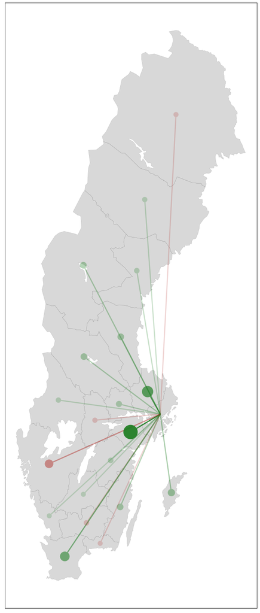

```python
bkr_kwargs = dict(
    facecolor = "grey",
    alpha = 0.3,
    edgecolor = "black",
    linewidth = 0.3
)

val_mat = np.array(dataset["value"]).reshape((len(ind_in), len(ind_ut)))
upper = np.triu(val_mat)
lower = np.tril(val_mat)
df_diff = pd.DataFrame(lower - upper.T)
df_diff = pd.DataFrame(df_diff.values + df_diff.values.T)

df_diff.columns = [x[3:].replace("_", " ") for x in df_2020.columns.values]
df_diff.index = df_diff.columns

df = df_diff.unstack().reset_index()

df.columns = ["In", "Ut", "N"]

mov = df.merge(gdf[["lnnamn", "centroid"]], left_on="In", right_on="lnnamn")
mov = mov.merge(gdf[["lnnamn", "centroid"]], left_on="Ut", right_on="lnnamn")
mov = mov[mov["N"] != 0 ]
mov = gpd.GeoDataFrame(mov)

mov["geometry"] = mov.apply(lambda row: LineString((row.centroid_x, row.centroid_y)), axis=1)
mov = mov.set_crs("epsg:3006")

lan = "Stockholms"

df_plot = mov[(mov["Ut"].str.contains(lan)) & (~mov["In"].str.contains(lan))].copy()

rgba_colors = np.zeros((len(df_plot.index), 4))
rgba_colors[:, 3] = minmax(abs(df_plot["N"]), min_a = 0.2, max_a = 0.9)

gr = (24, 123, 28)
red = (177, 42, 37)

for ind, N in enumerate(df_plot["N"].values):
    if N > 0:
        for ii, col in enumerate(gr):
            rgba_colors[ind, ii] = col/255
    else:
        for ii, col in enumerate(red):
            rgba_colors[ind, ii] = col/255

df_plot["size"] = minmax(abs(df_plot["N"].values), 7000, 20000)
df_plot["centroid_buffer"] = df_plot.apply(lambda x: x["centroid_x"].buffer(x["size"]), axis=1)
df_plot["clipped_lines"] = df_plot.apply(lambda x: x["geometry"].difference(x["centroid_buffer"]), axis=1)

fig, ax = plt.subplots(figsize = (25, 25))
ax.set(xticks = [], yticks = [])

gdf.plot(ax = ax, **bkr_kwargs)

df_plot.set_geometry("clipped_lines").plot(
    ax = ax,
    color = rgba_colors,
    linewidth = 2.5,
    zorder = 3,
)

df_plot.set_geometry("centroid_buffer").plot(
    ax = ax,
    facecolor= rgba_colors,
    zorder=4
)

data_sankey = df_diff.filter(like=lan, axis=0).squeeze()
data_sankey = data_sankey[~data_sankey.index.str.contains(lan)]

name = data_sankey.name.replace("_", "").strip("län")

label = [name]
label.extend([x.replace("_", "").strip("län") for x in data_sankey.index.values])

target = [ii for ii, _ in enumerate(label) if ii > 0 ]
src = np.zeros(len(target))

colors = ["rgba(" + ",".join(str(x) for x in line) + ")" for line in rgba_colors]
```

```python
sankeyfig = go.Figure(data = [go.Sankey(
    node = dict(
        pad = 5,
        thickness = 10,
        line = dict(color="black", width = 0.1),
        label = label,
        color=colors[0]
    ),
    link = dict(
        source = src,
        target = target,
        value = abs(data_sankey.values),
        color = colors,
    )
)])

sankeyfig.update_layout(title_text="Basic Sankey Diagram", font_size=10)
sankeyfig.write_html("sank2.html")

from IPython.display import IFrame
IFrame(src='./sank2.html', width=1000, height=600)
```

[interactive chart not shown]